# Ditching

NO_AIVS_001

Authors

Affiliations

Aud Helen Halbritter

University of Bergen

Ken Olaf Storaunet

Norwegian Institute of Bioeconomy Research

Mari Jönsson

Norwegian Institute for Nature Research

Oliver Snoksrud

Norwegian Institute of Bioeconomy Research

Ulrika Jansson Asplund

Norwegian Institute for Nature Research

Published

June 9, 2026

Reviewed by

Matthew Grainger

> **Recommended citation**: Halbritter, A. H., Storaunet, K. O., Jönsson, M., Snoksrud, O., and Jansson Asplund, U. 2026. Ditching (ID(s): NO_AIVS_001) v. 1.0.0. ecRxiv: https://github.com/NINAnor/ecRxiv/tree/main/indicators/NO_AIVS_001

**Metadata**

Table 1: Indicator metadata

| Variable | Value |
| --- | --- |
| Indicator ID | NO_AIVS_001 |
| Indicator Name | Ditching |
| verbatimName | Grøfting |
| Country | Norway |
| Continent | Europe |
| Ecosystem Condition Typology Class | A1 Physical State Characteristics |
| Realm | Terrestrial (T) |
| Biome | T2 Temperate-boreal forests and woodlands biome |
| Ecosystem | T2.1 Boreal/montane forests; T2.2 Deciduous temperate forests |
| Year added | 2026 |
| Last update | 2026 |
| Version | 1.0.0 |
| Version comment | ecTools workflow; national refs X0 = 0% intact water table area share, X100 = 100%; area basis defined by VEG_TYPE and VEGTYPE_FUKT combinations in data/ArealGrunnlag_Groftet_Drenerbart_areal.csv |
| Normalised | TRUE |
| Spatial aggregation pathway | Aggregate (NFI plots to county) - [Scale] - Aggregate (geographic region) - Aggregate (national level) |
| Precision | Approximate 95% bootstrap interval (2.5th–97.5th percentile of 1000 bootstrap draws) as inferential uncertainty around the point estimate (median). At county or sub-county level, bootstrapping is appl… |

**Log**

- 10 Jun. 2026 - ecTools workflow; GROFTET and area basis from ArealGrunnlag_Groftet.xlsx
- 03 Jul. 2026 - Update calculation of indicator using GROFTET and area basis from ArealGrunnlag_Groftet_Drenerbart_areal.csv
- 17 Jul. 2026 - Accepted
- 11 August 2026 - Minor update to metadata

## 1. Summary

We have used the NFI variable `groftet` where only drained/not drained is recorded. There are other variables recorded in the NFI describing types of ditching and drainage effect, eventually also effects on the ground floor vegetation. These data should be evaluated for use in future versions of the indicator. Terrain slope could also be evaluated in such development. The current selection of vegetation types (`veg_type`) and their relative moisture condition (`vegtype_fukt`) should also be scrutinized. The current area basis includes 85 % of the Norwegian forest, and mainly very dry forest vegetation types have been excluded. Thus, there is potential to develop this indicator further.

## 2. About the underlying data

### 2.1 Spatial and temporal extent, resolution, and representativity

The indicator is generally calculated for five-year reporting periods, based on the NFI data across Norwegian forest land. However, the GROFTET variable is only available from 2016 onwards. Thus, the first of the two reporting periods (2015-2019) only includes 4 of 5 years in a full NFI cycle (cf. Section 9 below).

### 2.2 Sampling design

There are about 12 000 NFI plots in forest ecosystems, distributed on a regular grid, with varying grid density for forest below/above the coniferous forest line and in Finnmark county (Viken 2025). The indicator is based on observations from NFI, where ditching since 2016 has been recorded within a 0.1 ha observation area surrounding each 250 m2 inventory plot. In most cases, the observation area is circular with a radius of 17.8 m. However, where stand boundaries or other land-cover types intersect this distance, the shape of the observation area is adjusted while maintaining the total area of 0.1 ha.

Drainage ditches are recorded if present within the observation area. Because ditches may occur along stand boundaries or adjacent land-cover types, they can be located at the edge of the observation area. When a ditch forms the boundary between two forest stands, it is assigned to the stand for which it is considered to have the greatest drainage effect.

### 2.3 Original units

At plot level, the NFI variable `groftet` uses code 1 for ditched plots and code 2 for not ditched (intact water table). Only plots with non-missing `groftet` codes 1 or 2 are used; missing values are excluded. Aggregated values are the area-weighted mean proportion of area with intact water table.

### 2.4 Instructions for citing, using and accessing data

The data used for this indicator have been made available by the Norwegian National Forest Inventory under a specific data use agreement of 2026-05-29, between NIBIO and the specified users. Further use of these data requires a separate data user agreement with NIBIO.

## 3. Indicator properties

### 3.1 Ecosystem Condition Typology Class (ECT)

A1 Physical State Characteristics

### 3.2 Ecosystem condition characteristic

The indicator represents the area proportion of the forest with intact hydrology.

### 3.3 Collinearities with other indicators

None of the other indicators describe the same aspect of ecological status as this indicator.

### 3.4 Impact factors

The most important impact factors affecting the water table in peatland forests, swamp forests and wet forests on mineral soil is drainage for forest production, agriculture or road construction.

## 4. Reference condition and levels

### 4.1 Reference condition

The reference condition is considered to be intact water levels in forest ecosystems where effects of human activities are clearly subordinate to those of natural ecosystem processes and disturbances.

## 5. Uncertainties

### 5.1 General uncertainties

The reported uncertainty reflects sampling variability but does not account for potential errors in field observations or ecological uncertainty. In particular, the indicator records the presence of drainage ditches rather than their current hydrological effects and assumes that presence of ditches is an adequate proxy for altered water-table conditions. It does not account for ditch characteristics, precise location or variation in the ditches’ hydrological effects. Observer judgement in recording ditches and assigning boundary ditches, as well as uncertainty in the definition of the area basis, may also influence estimates. While the intention of omitting certain forest areas was to include only forest areas where ditching has a documented effect on the water table and the species composition, the omittance criteria needs to be developed to better meet these intensions.

### 5.2 Reported uncertainties

County non-scaled values are bootstrapped with 1000 draws per county per reporting period. County draws are linearly scaled using the reference levels *X<sub>0</sub>* and *X<sub>100</sub>*. Uncertainty is propagated when aggregating to regional and national levels.

## 6. References

Viken, K. O. 2025. *Landsskogtakseringens feltinstruks — 2025*. Vol. 7. 5. NIBIO Bok.

## 7. Import and prepare datasets

### 7.1 Ditching

The NFI records ditching status in `groftet` (code 1 = ditched, code 2 = not ditched). Mesic, moist or wet forest types where ditching may affect drainage are listed in the area basis table (`data/ArealGrunnlag_Groftet_Drenerbart_areal.csv`; column `arealgrunnlag_groftet_final == 1` for combinations of `veg_type` and `vegtype_fukt`).

**Load data**

```r
lsk_data_file <- here("data/LSK_data_okologisk_tilstand_2026-06-03.csv")
areal_grunnlag_file <- here("data/ArealGrunnlag_Groftet_Drenerbart_areal.csv")

lsk_data_raw <- read_csv(
  lsk_data_file,
  show_col_types = FALSE,
  locale = locale(encoding = "UTF-8")
) |>
  clean_names()

areal_grunnlag <- read_delim(
  areal_grunnlag_file,
  delim = ";",
  show_col_types = FALSE,
  locale = locale(encoding = "UTF-8", decimal_mark = ".", grouping_mark = ",")
) |>
  dplyr::transmute(
    veg_type_fukt = VegType_Fukt,
    is_ditchable = ArealGrunnlag_GROFTET_final == 1L
  )
```

## 8. Spatial units

Aggregated indicator values are reported for counties, regions and nationally. Where counties are split into parts, those parts are merged to a single county name before aggregation. Aggregated indicator values should not be applied for spatial units finer than those that allow reliable estimates.

## 9. Analyses

### 9.1 Prepare data and create derived variables

This section prepares the NFI plot data for indicator calculation. We define five-year reporting periods for 2015–2019 and 2020–2024.

**Define reporting periods**

```r
reporting_periods <- list(
  "2015-2019" = 2015:2019,
  "2020-2024" = 2020:2024
)
```

We retain plots with `groftet` codes 1 or 2 and attach `is_ditchable` from the area-basis table (`arealgrunnlag_groftet_final`). Split NFI county labels are standardised by merging county parts to a single county name. For each plot, `is_ditched` is 1 when `groftet == 1` and 0 otherwise. Area-weighted contributions are `ditched_weighted = is_ditched * au_areal` and `ditchable_area_weighted = is_ditchable * au_areal`.

**Create derived variables**

```r
lsk_data <- lsk_data_raw |>
  mutate(veg_type_fukt = paste0(veg_type, "-", vegtype_fukt)) |>
  dplyr::left_join(areal_grunnlag, by = "veg_type_fukt") |>
  dplyr::mutate(is_ditchable = dplyr::coalesce(is_ditchable, FALSE)) |>
  filter(!is.na(groftet), groftet %in% c(1, 2)) |>
  mutate(
    fylke_name = region_fylke |>
      stringr::str_remove("^\\d+-\\d+\\s+") |>
      stringr::str_remove("^\\d+\\s*") |>
      stringr::str_squish(),
    fylke_name = normalize_county_parts(fylke_name),
    fylke_name_clean = stringi::stri_trans_general(
      stringr::str_squish(
        tolower(stringr::str_replace_all(fylke_name, "[0-9.-]", " "))
      ),
      "Latin-ASCII"
    ),
    region_code = assign_region_code(fylke_name_clean),
    region_name = assign_region_name(region_code),
    is_ditched = groftet == 1L,
    ditched_weighted = is_ditched * au_areal,
    ditchable_area_weighted = is_ditchable * au_areal
  )
```

Finally, we retain only the columns required for subsequent aggregation and reporting.

**Select downstream fields**

```r
lsk_data <- lsk_data |>
  dplyr::select(
    sesong,
    au_areal,
    arealtype,
    region_code,
    region_name,
    fylke_name,
    fylke_name_clean,
    veg_type,
    vegtype_fukt,
    veg_type_fukt,
    groftet,
    is_ditched,
    is_ditchable,
    ditched_weighted,
    ditchable_area_weighted
  )
```

### 9.2 Calculate non-scaled area-weighted indicator values

For each reporting period, we calculate values separately for counties, regions, and Norway. Within each geographic unit, we first sum plot-level area weights across all assessed plots (`sum(au_areal)`).

The non-scaled variable `ditched_share` is the share of that total area that is ditched: we add `ditched_weighted` across plots and divide by total assessed area.

The lower reference `ditchable_share` (*X<sub>0</sub>*) is calculated by dividing `ditchable_area_weighted` by total assessed area. This is the share of total assessed area where forest types can be ditched (`is_ditchable`). This is the maximum ditched share the unit could reach if all ditchable forest were ditched. Both `ditched_share` and `ditchable_share` are proportions on the 0–1 scale.

The scaled indicator value (0–1) is then `1 - ditched_share / ditchable_share` when `ditchable_share` > 0 (implemented in `scale_aivs_value()` via `ecTools::ec_normalise()`). Point estimates of `ditched_share`, `ditchable_share`, and `scaled_value` are returned by `calculate_aivs_period()` via `summarise_aivs()`.

**Calculate non-scaled values**

```r
aivs_results <- purrr::imap(
  reporting_periods,
  ~ calculate_aivs_period(lsk_data, .y, .x)
) |>
  purrr::compact()

aivs_results_county_all_periods   <- purrr::map_dfr(aivs_results, "county")
aivs_results_region_all_periods   <- purrr::map_dfr(aivs_results, "region")
aivs_results_national_all_periods <- purrr::map_dfr(aivs_results, "national")
```

### 9.3 Bootstrap draws per county

For each county and period, NFI plots are resampled with replacement 1000 times. Each bootstrap replicate recalculates `ditched_share` and `ditchable_share` from the resampled plots and applies the same scaling rule as in §9.2 (`scaled_value = 1 - ditched_share / ditchable_share` for that replicate). The resulting `scaled_value` draws are used for county uncertainty and for `ec_upscale()` in §9.4.

**Bootstrap draws per county (1000 per county per period)**

```r
county_draws_long <- purrr::imap_dfr(aivs_results, function(period_result, period_name) {
  county_meta <- period_result$county |>
    dplyr::select(fylke_name, total_area, region_code)

  purrr::imap_dfr(
    split(period_result$data, period_result$data$fylke_name),
    function(county_data, county_name) {
      boot <- bootstrap_aivs(county_data, n_bootstrap = 1000)
      dplyr::tibble(
        period            = period_name,
        fylke_name        = county_name,
        sim_id            = seq_along(boot$draws),
        ditched_share     = boot$draws,
        ditchable_share   = boot$ditchable_share_draws,
        scaled_value      = boot$scaled_draws
      )
    }
  ) |>
    dplyr::left_join(county_meta, by = "fylke_name")
})
```

The table below (Table 2) shows the area-weighted share of ditched forest per county for all reporting periods, with approximate 95% bootstrap confidence intervals (2.5th–97.5th percentile of 1000 draws).

Table 2: Non-scaled ditched area share (%) by county for all reporting periods. Point estimate is the direct area-weighted mean from section 9.2; 95% CI is derived from 1000 bootstrap draws. Note: the first reporting period (2015–2019) is based on data from 2016–2019 only, as groftet is only available from 2016.

| Period | County | Region | Ditched area share (%) | Ditchable share (X0, %) | 95% CI | Total area (ha) | Number of plots |
| --- | --- | --- | --- | --- | --- | --- | --- |
| 2015-2019 | Buskerud | Øst | 3.85 | 76.54 | 2.5 – 5.4 | 616260.386 | 695 |
| 2015-2019 | Hedmark | Øst | 7.86 | 75.18 | 6.52 – 9.17 | 1354898.2562 | 1507 |
| 2015-2019 | Oppland | Øst | 6.49 | 86.54 | 5.04 – 8.16 | 778113.1022 | 870 |
| 2015-2019 | Oslo og Akershus | Øst | 7.69 | 84.27 | 5 – 10.5 | 280194.8942 | 347 |
| 2015-2019 | Vestfold | Øst | 9.47 | 89.77 | 4.71 – 15.2 | 106616.4554 | 134 |
| 2015-2019 | Østfold | Øst | 10.64 | 67.69 | 6.8 – 14.48 | 227021.8522 | 270 |
| 2015-2019 | Agder | Sør | 5.08 | 77.01 | 3.7 – 6.61 | 727342.7274 | 819 |
| 2015-2019 | Telemark | Sør | 3.9 | 76.78 | 2.6 – 5.39 | 658232.8868 | 741 |
| 2015-2019 | Hordaland | Vest | 2.5 | 93.8 | 1.15 – 4.11 | 360574.6876 | 408 |
| 2015-2019 | Rogaland | Vest | 3.29 | 83.13 | 1.43 – 5.54 | 229888.5718 | 228 |

[output cut: 22 more lines]

### 9.4 Scale indicator values and aggregate to regional and national levels

Reference levels are *X<sub>100</sub>* = 0% ditched (`ditched_share` = 0) and a unit-specific *X<sub>0</sub>* = `ditchable_share` (when all ditchable forest in the unit is ditched). Scaling uses the linear relationship in §9.2; values outside [0, 1] are truncated at scaling when `ditched_share` exceeds `ditchable_share`. Each county’s 1000 bootstrap draws from section 9.3 already include `scaled_value`; §9.4 does not apply a separate scaling step. Figure 1 shows the mapping for a sample of draws.

**Prepare scaled county draws and county uncertainty summaries**

```r
county_draws_scaled <- county_draws_long |>
  dplyr::mutate(nation = "National")

county_scaled_with_uncertainty <- county_draws_scaled |>
  dplyr::group_by(period, fylke_name, total_area, region_code) |>
  dplyr::summarise(
    median = median(scaled_value, na.rm = TRUE),
    p_025  = as.numeric(quantile(scaled_value, 0.025, na.rm = TRUE)),
    p_25   = as.numeric(quantile(scaled_value, 0.25, na.rm = TRUE)),
    p_75   = as.numeric(quantile(scaled_value, 0.75, na.rm = TRUE)),
    p_975  = as.numeric(quantile(scaled_value, 0.975, na.rm = TRUE)),
    .groups = "drop"
  ) |>
  dplyr::left_join(
    aivs_results_county_all_periods |> dplyr::select(period, fylke_name, n_plots),
    by = c("period", "fylke_name")
  )
```

**Normalisation diagnostic figure**

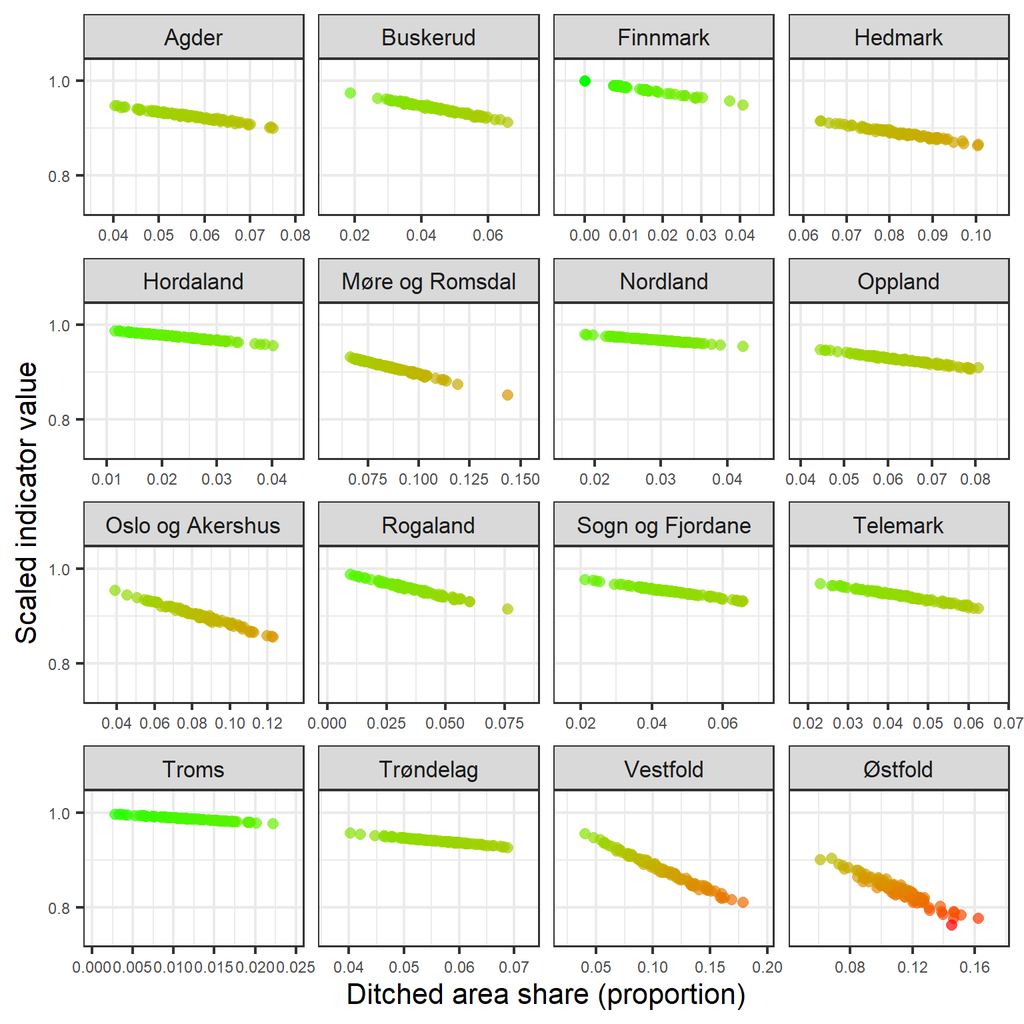

Figure 1: Linear normalisation of ditched area share (proportion) to indicator values (0–1), with truncation when ditched share exceeds the unit-specific ditchable forest share. Each panel shows one county, with its own *X<sub>0</sub>* (`ditchable_share` from section 9.2). The x-axis is free-scaled per panel to reflect the range of resampled non-scaled ditched shares in that county. Points are a random sample of up to 100 bootstrap draws (out of 1000) per county, pooled across reporting periods, illustrating resampled area-weighted ditched shares and their scaled values. *X<sub>100</sub>* = 0% ditched (best condition); *X<sub>0</sub>* is the county-specific ditchable forest share (worst condition when all ditchable forest in the unit is ditched).

```r
norm_plot_data <- county_draws_scaled |>
  dplyr::group_by(fylke_name) |>
  dplyr::group_modify(~ dplyr::slice_sample(.x, n = min(100, nrow(.x)))) |>
  dplyr::ungroup()

aivs_norm_plot <- ec_norm_plot(
  norm_plot_data$ditched_share,
  norm_plot_data$scaled_value
) +
  ggplot2::facet_wrap(~ norm_plot_data$fylke_name, scales = "free_x") +
  ggplot2::labs(
    x = "Ditched area share (proportion)",
    y = "Scaled indicator value"
  ) +
  ggplot2::theme(axis.text = ggplot2::element_text(size = 9))
aivs_norm_plot$layers[[1]]$aes_params$size <- 3

suppressMessages(
  ggsave(
    filename = here::here("img/aivs_norm_plot.png"),
    plot = aivs_norm_plot,
    scale = 1.5
  )
)

aivs_norm_plot
```

The scaled draws are then passed to `ecTools::ec_upscale()`, which propagates uncertainty through the spatial hierarchy. For each of 1000 Monte Carlo iterations, one draw is sampled per county and the area-weighted mean gives one regional value; a second `ec_upscale()` call repeats this from regions to national level.

**ec_upscale: county to region (compute once, save RDS)**

```r
aivs_mc_cache_deps <- c(
  lsk_data_file,
  areal_grunnlag_file,
  here::here("R/functions.R"),
  here::here("R/NO_AIVS_001.qmd")
)
aivs_mc_rds_regional <- here::here("data/aivs_mc_regional.rds")

if (
  file.exists(aivs_mc_rds_regional) &&
  file.mtime(aivs_mc_rds_regional) >= max(file.mtime(aivs_mc_cache_deps), na.rm = TRUE)
) {
  aivs_mc_regional <- readRDS(aivs_mc_rds_regional)
} else {
  aivs_mc_regional <- ecTools::ec_upscale(
    data        = county_draws_scaled,
    variable    = scaled_value,
    weight      = total_area,
    start_units = fylke_name,
    end_units   = region_code,
    year        = period,
    end_units_name = "region_code",
    n = 1000
  )
  saveRDS(aivs_mc_regional, aivs_mc_rds_regional)
}
```

**ec_upscale: region to national (compute once, save RDS)**

```r
region_area_weights <- county_draws_scaled |>
  dplyr::distinct(period, fylke_name, total_area, region_code) |>
  dplyr::group_by(period, region_code) |>
  dplyr::summarise(region_area = sum(total_area), .groups = "drop")

aivs_mc_regional_for_national <- aivs_mc_regional |>
  dplyr::left_join(region_area_weights, by = c("period", "region_code")) |>
  dplyr::mutate(nation = "National")

aivs_mc_rds_national <- here::here("data/aivs_mc_national.rds")

if (
  file.exists(aivs_mc_rds_national) &&
  file.mtime(aivs_mc_rds_national) >= max(
    c(file.mtime(aivs_mc_cache_deps), file.mtime(aivs_mc_rds_regional)),
    na.rm = TRUE
  )
) {
  aivs_mc_national <- readRDS(aivs_mc_rds_national)
} else {
  aivs_mc_national <- ecTools::ec_upscale(
    data        = aivs_mc_regional_for_national,
    variable    = sampled_mean,
    weight      = region_area,
    start_units = region_code,
    end_units   = nation,
    year        = period,
    end_units_name = "nation",
    n = 1000
  )
  saveRDS(aivs_mc_national, aivs_mc_rds_national)
}
```

**Combine regional and national MC draws; build summary tables**

```r
aivs_mc_combined <- dplyr::bind_rows(
  aivs_mc_regional |> dplyr::select(period, region = region_code, sampled_mean),
  aivs_mc_national |> dplyr::select(period, region = nation, sampled_mean)
)

county_scaled_all_periods <- aivs_results_county_all_periods |>
  dplyr::select(period, fylke_name, scaled_value, ditchable_share, ditched_share)

region_scaled_agg_all_periods <- aivs_mc_regional |>
  dplyr::group_by(period, region_code) |>
  dplyr::summarise(scaled_value = median(sampled_mean), .groups = "drop") |>
  dplyr::mutate(region_name = assign_region_name(region_code))

national_scaled_agg_all_periods <- aivs_mc_national |>
  dplyr::group_by(period) |>
  dplyr::summarise(scaled_value = median(sampled_mean), .groups = "drop") |>
  dplyr::mutate(region = "National")

region_scaled_agg_with_uncertainty <- aivs_mc_regional |>
  dplyr::group_by(period, region_code) |>
  dplyr::summarise(
    median = median(sampled_mean),
    p_025  = as.numeric(quantile(sampled_mean, 0.025)),
    p_25   = as.numeric(quantile(sampled_mean, 0.25)),
    p_75   = as.numeric(quantile(sampled_mean, 0.75)),
    p_975  = as.numeric(quantile(sampled_mean, 0.975)),
    .groups = "drop"
  ) |>
  dplyr::mutate(region_name = assign_region_name(region_code)) |>
  dplyr::left_join(
    aivs_results_region_all_periods |> dplyr::select(period, region_code, total_area, n_plots),
    by = c("period", "region_code")
  )

national_scaled_agg_with_uncertainty <- aivs_mc_national |>
  dplyr::group_by(period) |>
  dplyr::summarise(
    median = median(sampled_mean),
    p_025  = as.numeric(quantile(sampled_mean, 0.025)),
    p_25   = as.numeric(quantile(sampled_mean, 0.25)),
    p_75   = as.numeric(quantile(sampled_mean, 0.75)),
    p_975  = as.numeric(quantile(sampled_mean, 0.975)),
    .groups = "drop"
  ) |>
  dplyr::mutate(region = "National") |>
  dplyr::left_join(
    aivs_results_national_all_periods |> dplyr::select(period, total_area, n_plots),
    by = "period"
  )
```

Truncation may apply when the ditched area share exceeds the unit-specific `ditchable_share` (*X<sub>0</sub>*); scaled values outside [0, 1] are truncated at scaling.

The figure below (Figure 2) summarises regional and national indicator values by reporting period.

**Time series of indicator values by region and period**

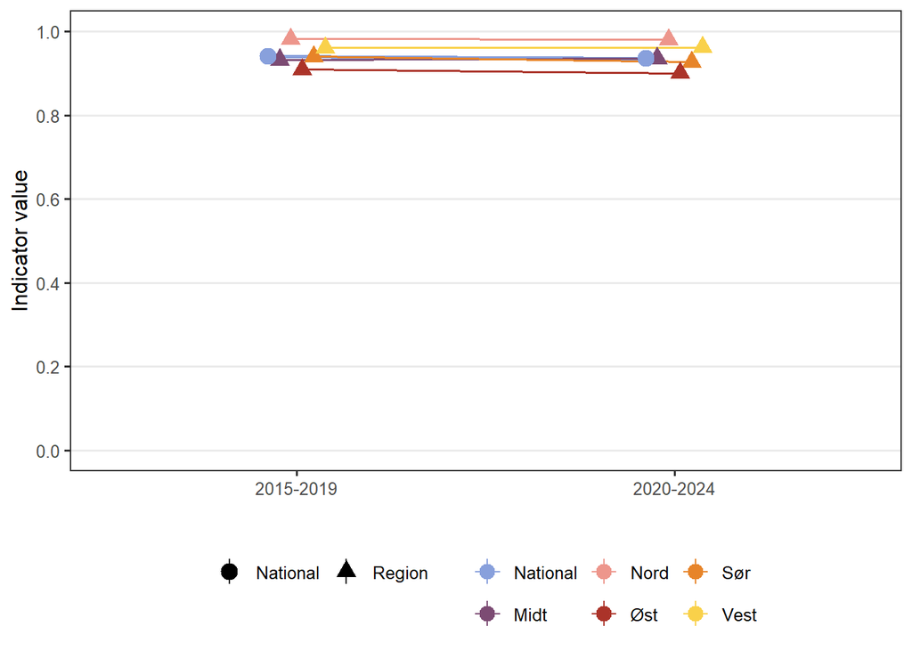

Figure 2: Indicator values for ditched area share by region and reporting period. Points show the MC median; error bars are 95% credible intervals from the Monte Carlo propagation. National values use filled circles and a thicker line. Note: the first reporting period (2015–2019) is based on data from 2016–2019 only, as groftet is only available from 2016.

```r
aivs_region_labels <- c(
  "1" = "Øst", "2" = "Sør", "3" = "Vest",
  "4" = "Midt", "5" = "Nord", "National" = "National"
)
aivs_region_levels <- c("National", "Midt", "Nord", "Øst", "Sør", "Vest")
aivs_region_cols <- setNames(
  MetBrewer::met.brewer("Archambault", n = length(aivs_region_levels)),
  aivs_region_levels
)

aivs_plot_data <- aivs_mc_combined |>
  dplyr::mutate(
    region_name = dplyr::recode(region, !!!aivs_region_labels),
    series_type = dplyr::if_else(region == "National", "National", "Region")
  ) |>
  dplyr::group_by(period, region_name, series_type) |>
  dplyr::summarise(
    median = median(sampled_mean),
    p_025  = as.numeric(quantile(sampled_mean, 0.025)),
    p_975  = as.numeric(quantile(sampled_mean, 0.975)),
    .groups = "drop"
  ) |>
  dplyr::mutate(region_name = factor(region_name, levels = aivs_region_levels))

ggplot2::ggplot(
  aivs_plot_data,
  ggplot2::aes(x = period, y = median, colour = region_name, group = region_name)
) +
  ggplot2::geom_line(
    ggplot2::aes(linewidth = series_type),
    position = ggplot2::position_dodge(width = 0.18)
  ) +
  ggplot2::geom_pointrange(
    ggplot2::aes(ymin = p_025, ymax = p_975, shape = series_type),
    size = 0.8, linewidth = 0.45,
    position = ggplot2::position_dodge(width = 0.18)
  ) +
  ggplot2::scale_colour_manual(values = aivs_region_cols, name = NULL) +
  ggplot2::scale_shape_manual(values = c(National = 19, Region = 17), name = NULL) +
  ggplot2::scale_linewidth_manual(values = c(National = 1, Region = 0.55), guide = "none") +
  ggplot2::scale_y_continuous(limits = c(0, 1), breaks = seq(0, 1, 0.2)) +
  ggplot2::theme_bw(base_size = 12) +
  ggplot2::theme(
    legend.position    = "bottom",
    legend.box         = "horizontal",
    panel.grid.minor   = ggplot2::element_blank(),
    panel.grid.major.x = ggplot2::element_blank()
  ) +
  ggplot2::guides(
    colour = ggplot2::guide_legend(
      nrow = 2,
      override.aes = list(size = 0.7, linewidth = 0.45)
    ),
    shape  = ggplot2::guide_legend(override.aes = list(size = 0.8, linewidth = 0.45))
  ) +
  ggplot2::labs(y = "Indicator value", x = "")
```

## 10. Results

The following tables present scaled indicator results at county, regional, and national scales by reporting period. Tables report the median as the indicator value, with an approximate 95% interval (2.5% and 97.5% quantiles) and an approximate interquartile range (25% and 75% quantiles). Scaled values are on a 0–1 scale, where 1 corresponds to 0% ditched area share (*X<sub>100</sub>*) and 0 corresponds to a ditched area share equal to the unit-specific ditchable forest share (*X<sub>0</sub>*).

### 10.1 County-level results (scaled with uncertainty)

Table 3: County indicator values for ditched area share by reporting period. Values are scaled to 0–1 using unit-specific X0 (ditchable forest share) and X100 = 0% ditched. Uncertainty is derived from 1000 bootstrap draws. The median is reported as the indicator value, with approximate 95% and interquartile intervals from the scaled draw distribution. Note: the first reporting period (2015–2019) is based on data from 2016–2019 only, as groftet is only available from 2016.

| ECT | Indicator | ID | Accounting area | Region | Ecosystem | Reporting period | Indicator value | 95% CI | 50% CI | Number of plots |
| --- | --- | --- | --- | --- | --- | --- | --- | --- | --- | --- |
| A1 | Ditched area share | NO_AIVS_001 | Buskerud | Øst | Boreal/montane forests | 2015-2019 | 0.95 | 0.93 - 0.97 | 0.94 - 0.96 | 695 |
| A1 | Ditched area share | NO_AIVS_001 | Hedmark | Øst | Boreal/montane forests | 2015-2019 | 0.9 | 0.88 - 0.91 | 0.89 - 0.9 | 1507 |
| A1 | Ditched area share | NO_AIVS_001 | Oppland | Øst | Boreal/montane forests | 2015-2019 | 0.92 | 0.91 - 0.94 | 0.92 - 0.93 | 870 |
| A1 | Ditched area share | NO_AIVS_001 | Oslo og Akershus | Øst | Boreal/montane forests | 2015-2019 | 0.91 | 0.88 - 0.94 | 0.9 - 0.92 | 347 |
| A1 | Ditched area share | NO_AIVS_001 | Vestfold | Øst | Boreal/montane forests | 2015-2019 | 0.89 | 0.83 - 0.95 | 0.87 - 0.91 | 134 |
| A1 | Ditched area share | NO_AIVS_001 | Østfold | Øst | Boreal/montane forests | 2015-2019 | 0.84 | 0.79 - 0.9 | 0.82 - 0.86 | 270 |
| A1 | Ditched area share | NO_AIVS_001 | Agder | Sør | Boreal/montane forests | 2015-2019 | 0.93 | 0.91 - 0.95 | 0.93 - 0.94 | 819 |
| A1 | Ditched area share | NO_AIVS_001 | Telemark | Sør | Boreal/montane forests | 2015-2019 | 0.95 | 0.93 - 0.97 | 0.94 - 0.95 | 741 |
| A1 | Ditched area share | NO_AIVS_001 | Hordaland | Vest | Boreal/montane forests | 2015-2019 | 0.97 | 0.96 - 0.99 | 0.97 - 0.98 | 408 |
| A1 | Ditched area share | NO_AIVS_001 | Rogaland | Vest | Boreal/montane forests | 2015-2019 | 0.96 | 0.93 - 0.98 | 0.95 - 0.97 | 228 |

[output cut: 22 more lines]

### 10.2 Regional results (scaled with uncertainty)

Table 4: Regional indicator values for ditched area share by reporting period. Scaled values and uncertainty are derived from Monte Carlo propagation (1000 draws per region). The median is reported as the indicator value, with approximate 95% and interquartile intervals from the MC distribution. Note: the first reporting period (2015–2019) is based on data from 2016–2019 only, as groftet is only available from 2016.

| ECT | Indicator | ID | Accounting area | Ecosystem | Reporting period | Indicator value | 95% CI | 50% CI | Number of plots |
| --- | --- | --- | --- | --- | --- | --- | --- | --- | --- |
| A1 | Ditched area share | NO_AIVS_001 | Øst | Boreal/montane forests | 2015-2019 | 0.91 | 0.9 - 0.92 | 0.91 - 0.91 | 3,823 |
| A1 | Ditched area share | NO_AIVS_001 | Sør | Boreal/montane forests | 2015-2019 | 0.94 | 0.93 - 0.95 | 0.94 - 0.95 | 1,560 |
| A1 | Ditched area share | NO_AIVS_001 | Vest | Boreal/montane forests | 2015-2019 | 0.96 | 0.95 - 0.97 | 0.96 - 0.97 | 1,020 |
| A1 | Ditched area share | NO_AIVS_001 | Midt | Boreal/montane forests | 2015-2019 | 0.93 | 0.92 - 0.94 | 0.93 - 0.94 | 1,900 |
| A1 | Ditched area share | NO_AIVS_001 | Nord | Boreal/montane forests | 2015-2019 | 0.98 | 0.97 - 0.99 | 0.98 - 0.99 | 1,787 |
| A1 | Ditched area share | NO_AIVS_001 | Øst | Boreal/montane forests | 2020-2024 | 0.90 | 0.89 - 0.91 | 0.9 - 0.9 | 4,795 |
| A1 | Ditched area share | NO_AIVS_001 | Sør | Boreal/montane forests | 2020-2024 | 0.93 | 0.91 - 0.94 | 0.92 - 0.93 | 1,908 |
| A1 | Ditched area share | NO_AIVS_001 | Vest | Boreal/montane forests | 2020-2024 | 0.96 | 0.95 - 0.97 | 0.96 - 0.97 | 1,272 |
| A1 | Ditched area share | NO_AIVS_001 | Midt | Boreal/montane forests | 2020-2024 | 0.94 | 0.93 - 0.95 | 0.93 - 0.94 | 2,390 |
| A1 | Ditched area share | NO_AIVS_001 | Nord | Boreal/montane forests | 2020-2024 | 0.98 | 0.97 - 0.99 | 0.98 - 0.98 | 2,241 |

### 10.3 National results (scaled with uncertainty)

Table 5: National indicator values for ditched area share by reporting period. Scaled values and uncertainty are derived from Monte Carlo propagation (1000 draws). The median is reported as the indicator value, with approximate 95% and interquartile intervals from the MC distribution. Note: the first reporting period (2015–2019) is based on data from 2016–2019 only, as groftet is only available from 2016.

| ECT | Indicator | ID | Accounting area | Ecosystem | Reporting period | Indicator value | 95% CI | 50% CI | Number of plots |
| --- | --- | --- | --- | --- | --- | --- | --- | --- | --- |
| A1 | Ditched area share | NO_AIVS_001 | National | Boreal/montane forests | 2015-2019 | 0.94 | 0.94 - 0.95 | 0.94 - 0.94 | 10,090 |
| A1 | Ditched area share | NO_AIVS_001 | National | Boreal/montane forests | 2020-2024 | 0.94 | 0.93 - 0.94 | 0.93 - 0.94 | 12,606 |

## 11. Export file

Regional and national Monte Carlo draws are exported in one table (`aivs_mc_combined`: `period`, `region`, `sampled_mean`; `region` contains the five NI region codes and `"National"`).

**Export regional and national MC-propagated indicator draws**

```r
write.csv(
  aivs_mc_combined,
  here::here("data/results_NO_AIVS_001.csv"),
  row.names = FALSE
)
```

## 12. Author contributions

**CRediT statement**

- Conceptualization: [UJA, KOS]
- Methodology: [UJA, KOS, AHH]
- Data curation: [OS]
- Formal analysis: [AHH]
- Validation: [AHH, OS, KOS]
- Visualization: [AHH]
- Writing – original draft: [AHH, UJA]
- Writing – review & editing: [All]

**MeRIT attribution**

**Session Info**

This information is mainly aimed at developers that need to recreate the R environment that produced the html. Important note: this information is about the R session that was running when the html was rendered, and if some of the code chunks were not evaluated when the html was rendered, they may have been executed in a different environment.